## The Model

### Model Overview

This model tracks susceptibles, exposed/pre-symptomatic, infected/symptomatic and recovered hosts. The following compartments are included:

- **S** - uninfected and susceptible individuals
- **E** - individuals who are infected and do not yet show symptoms. Those individuals can be infectious.
- **I** - individuals who are infected and show symptoms. Those individuals are likely infectious, but the model allows to adjust this, including no infectiousness.
- **R** - recovered/removed individuals. Those individuals have recovered and are immune. They can lose their immunity.

The included processes/mechanisms are the following:

- Susceptible individuals (S) can become infected by pre-symptomatic/exposed (E) or symptomatic (I) hosts at rates *b<sub>E</sub>* and *b<sub>I</sub>*.
- All infected hosts first enter the exposed/presymptomatic stage and leave the stage at rate *g<sub>E</sub>*, the inverse of which is the average time spent in this stage.
- All infected hosts go from the presymptomatic to the symptomatic stage and leave the stage at rate *g<sub>I</sub>*.
- Recovered individuals are initially immune to reinfection. They can lose their immunity at rate *w* and return to the susceptible compartment.
- New susceptible hosts enter the system (are born) at rate *e*. Natural death occurs at rate *n*.

### Model Implementation

The flow diagram for the model implemented in this app is:

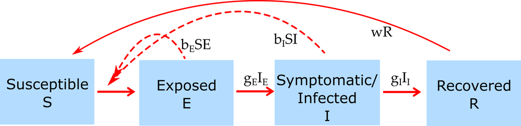

Flow diagram for this model.

Note that this model is *not* an ordinary differential equation model. It is instead its stochastic equivalent. We can specify the model by writing down every possible transition/event/reaction that can occur and their propensities (the propensity multiplied with the time step gives the probability that a given event/transition occurs). For our model these are the following:

| Event type | Transitions | Propensity |
| --- | --- | --- |
| Infection | S => S-1, E => E+1 | S(b<sub>E</sub>E+b<sub>I</sub>I) |
| Progression to Symptoms | E => E-1, I => I+1 | g<sub>E</sub>E |
| Recovery | I => I-1, R => R+1 | g<sub>I</sub>I |
| Waning of Immunity | R => R-1, S => S+1 | wR |
| Births | S => S+1 | eS |
| Death of susceptible | S => S-1 | nS |
| Death of exposed | E => E-1 | nE |
| Death of symptomatic | I => I-1 | nI |
| Death of recovered | R => R-1 | nR |